[figure not shown]

# Limits of Agreement

## What is a Limit of Agreement?

Simply put, calculating the limit of agreement (LoA) between two systems equates to estimating the expected difference and the predictive confidence band for this estimate. The estimated difference between the two systems is often referred to as the bias, whereas the confidence interval of prediction based on the estimate is what is actually termed the LoA. While many options exist for comparing systems, LoA’s are intuitive as they return the expected difference in actual measurement units which is practically meaningful. Additionally, this difference is returned in positive or negative units rather than an absolute error or root mean squared error which give no indication of whether there is a tendency to under or over estimate. Various approaches can be taken to estimate LoA’s, however, due to the way validation data is often collected with participants contributing multiple trials, we take a mixed model approach to the problem in this tutorial.

## Limits of Agreement with Mixed Models

From the mixed model it is also possible to perform inference on the estimated bias to determine whether it is statistically significant. This is approximately equivalent to a repeated measures t-test if working with a discrete variable or a repeated measures approach to statistical parametric mapping (SPM) if working with a functional variable.

## Discrete vs Functional Validation

The choice to perform discrete or functional validation of a system will depend on the intended purpose for collecting data. Discrete validation may be used to check the validity of how a system captures a distinct feature of a movement, e.g. peak knee flexion. This is appropriate when **ONLY** the discrete metric is of interest in downstream analysis. Examples of this may be comparing two force plate systems for calculating jump height from a counter movement jump or peak force production from an isometric mid-thigh pull. Functional refers to the fact that the data collected is assumed to be an observation of a continuous process and thus observations are treated as a “function” rather than as a discretised set of observations over time. Functional validation then provides the estimated bias and LoA across the whole observed movement rather than just one specific point. If data from the system being compared is intended to be used in forms of analysis that investigate movement in a holistic way such as statistical parametric mapping (SPM) or other forms of functional data analysis (FDA) we recommend taking a functional approach to validation.

# Case Study: Gait

In this case study we demonstrate both functional and discrete validation on a synthetic data set containing repeated observations of sagittal knee flexion from 20 participants during walking. Each for each trial there is an observation from the reference system (System 1) and the test system (System 2). The data set is generated from the `gait` data attached to the `fda` `R` package. We simulated 100 observations in total then created a copy of these observations which system specific, participant specific, and miscellaneous noise has been added to. As a resource we provide the code (including for the data generation) as a resource for future use at https://github.com/arlohook/AISValidation.git

## Data

To begin with we visually inspect the data with colours indicative of participant.

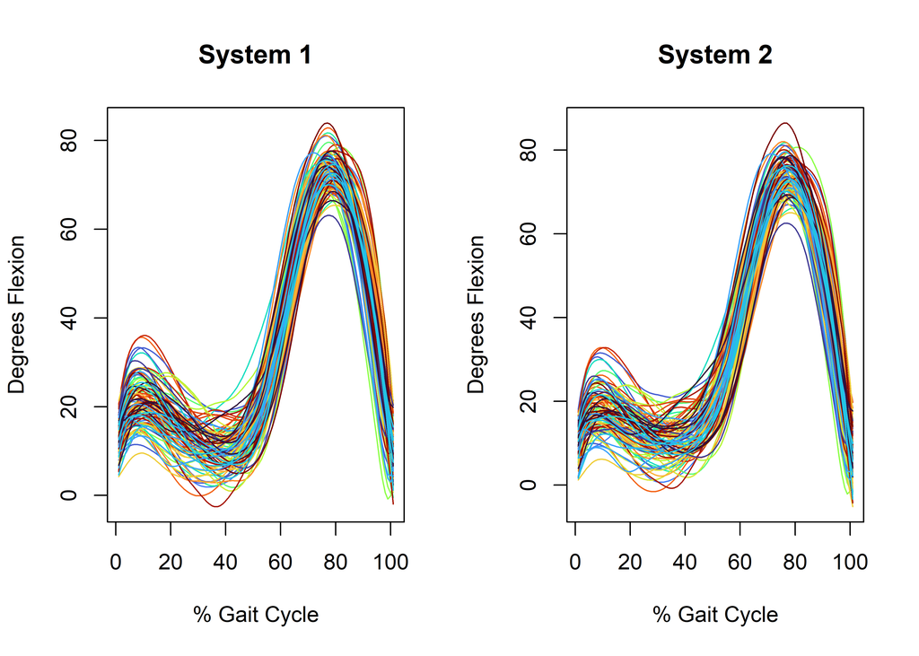

## Discrete Limit of Agreement

To demonstrate the estimation of a discrete limit of agreement we will focus on the peak knee flexion value recorded by each system. Since we have repeated measurements from each participant we will use a mixed model with a random intercept for each participant to account for this feature in the data. The process is performed as follows:

1. Calculate the peak knee flexion for each trial from each system
2. Calculate the trial level difference between systems as System 1 $-$ System 2
3. Estimate the expected value of this difference via a mixed model (this will be the fixed intercept estimate)
4. Estimate the error variance of this estimator and construct a 95% confidence interval which is the LoA
5. Visualise the results

We also obtain an estimate of the variance for participant specific bias as well as perform inference on the estimate of the system bias.

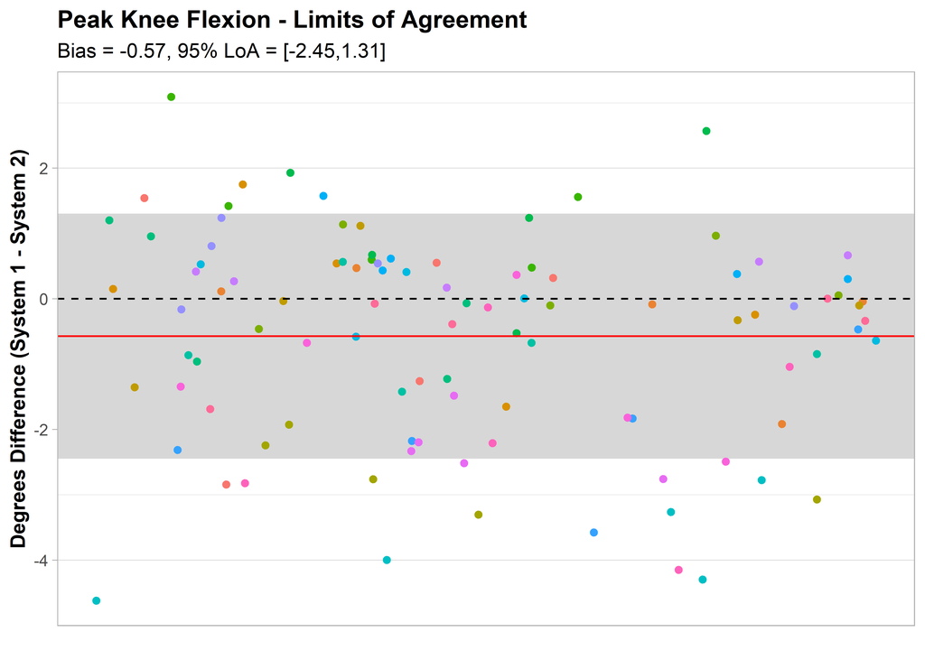

From the figure above we can see that there is a relative small bias, i.e. difference between the systems, with a fairly small LoA. Obviously the acceptable tolerance for the difference will depend on the metric and intended use of the system.

Next we can look at the variance of the random intercept i.e. the participant specific biases.

```
##  Groups      Name        Std.Dev.
##  Participant (Intercept) 1.29313
##  Residual                0.95738
```

What we are interested in from this output is the `Participant (Intercept)` value 1.29. For an intuition of what this means, if we were to look at the difference between the systems for a new participant it would be expected that they would bring their own participant specific difference drawn randomly from a normal distribution with a standard deviation of 1.29.

Finally we can look at the confidence intevals of the bias estimate to determine whether the bias is significant.

```
## Bias = -0.57, 95% CI = [-1.22,0.09]
```

Based on this result there is a non-significant difference between the two systems in their peak knee flexion angles as 0 is contained within the 95% CI. We note that this does not take into account the timing of this value only the magnitude of the derived measurement.

## Functional Limit of Agreement

Next we demonstrate functional LoA (FLoA) on the same data. This follows the same process as discrete LoA except we model the difference over time rather than at one discrete point. One key difference however is in the construction of the confidence bands for the bias estimate. We estimate a “simultaneous” band that aims to give 95% coverage across the whole domain, i.e. gait cycle, rather than the “point wise” estimate. Simultaneous bands aim to account for the repeated testing that happens across the function while leveraging the correlation structure in the data. The simultaneous band is constructed via a bootstrapping procedure with re-sampling at the participant level because of the multi-level structure of the data.

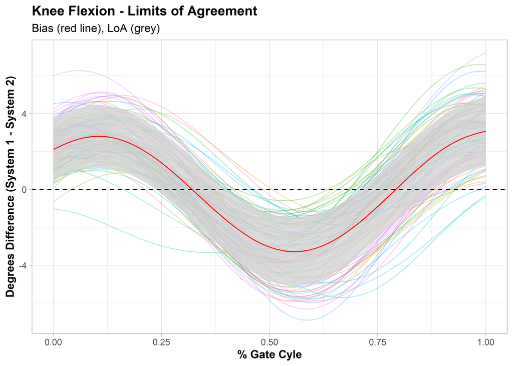

Based on the FLoA above we can see that the bias is larger at different point sin the domain than others and changes from positive to negative across the gait cycle. This is the benefit of a functional approach for a more general system validation as if we were to only look at the discrete analysis the 2 systems appear fairly comparable.

Next we can explore the participant specific variation of this bias. Due to software limitations we manually construct an estimate of this from the random intercept functions. We note in advance that this does not give an exact variance of the functional random intercepts assumed in the model, however, it may still provide some insight to where participant specific bias is most variable across the gait cycle.

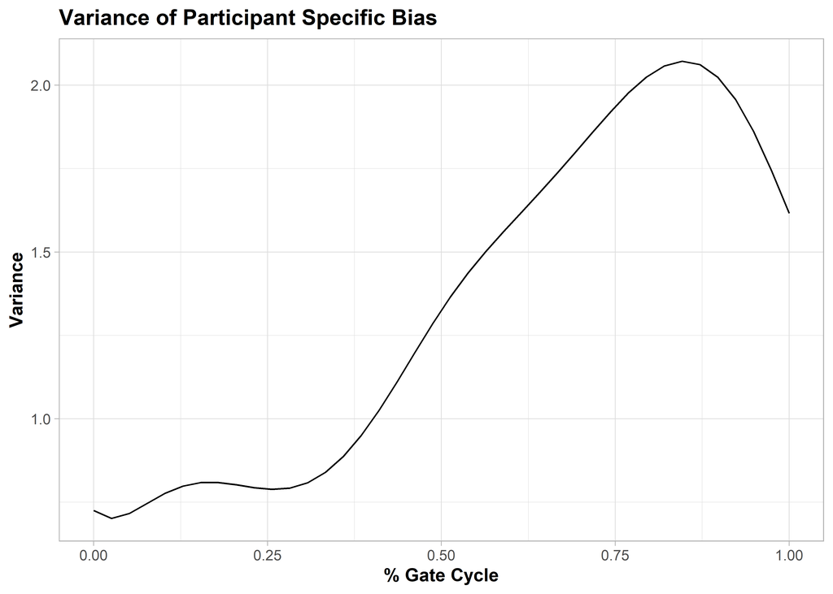

Based on the above figure, we can see that variability in differences arising from participant related factors grows across the gait cycle.

Finally, we can do inference on the bias function. This is done using a bootstrap at the participant level calculating the maximum t-statistic from each iteration to form an empirical distribution which is used to obtain the multiplier of the standard error of the bias estimate as opposed to the 1.96 that would be used to construct a “point wise” 95% CI.

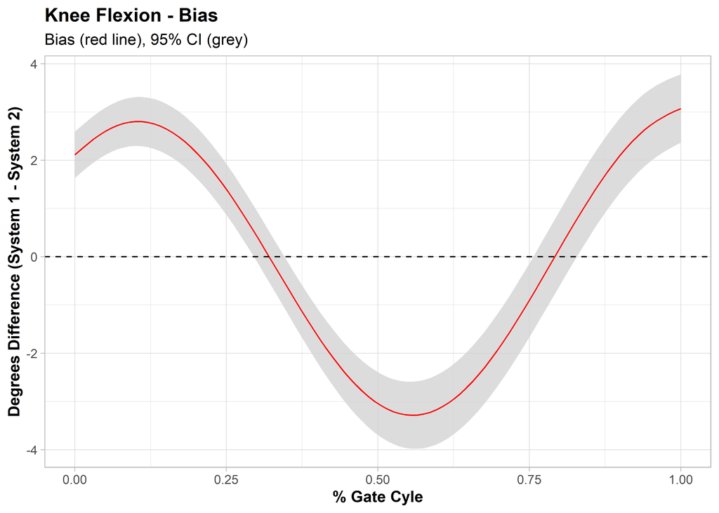

Based on this there is a significant bias across a large portion of the domain. Again this differs from the insight gained from the discrete LoA further highlighting the value of taking a functional approach unless a specific discrete metric is all that is of interest.